# R Notebook

JMJPFU 14-12-2016

This note book is to do all the activities required for premodelling. This would involve the following

1. Divide into train and test sets
2. Do cross validation to find the best algorithm
3. Fine tuning the algorithm
4. Find the feature importance
5. Get some intuitions on the list of features

# Dividing into train and test sets

```r
# Loading the required packages
library(mlbench)
library(caret)
```

Creating the validation dataset

```r
set.seed(7)
validationindex <- createDataPartition(Pre_train$class,p=0.80,list=FALSE) # Creating the index
validation <- Pre_train[-validationindex,] # Creating the validation set
train_set <- Pre_train[validationindex,] # Creating the training set
# Looking at distribution of classes in both validation and trainining sets
prop.table(table(validation$class))*100
```

```
      Bad_Portfolio-Bad      Bad_Portfolio-Good    Bad_Portfolio-Medium     Good_Portfolio-Good   Good_Portfolio-Medium
             0.08071025              0.02017756              0.00000000              0.10088781             35.87570621
  Medium_Portfolio-Good Medium_Portfolio-Medium
             0.06053269             63.86198547
```

```r
prop.table(table(train_set$class))*100
```

```
      Bad_Portfolio-Bad      Bad_Portfolio-Good    Bad_Portfolio-Medium     Good_Portfolio-Good   Good_Portfolio-Medium
             0.08066142              0.02016536              0.01008268              0.11595080             35.85400282
  Medium_Portfolio-Good Medium_Portfolio-Medium
             0.07562008             63.84351684
```

# Evaluating Algorithms : Baseline

Let us now create the baseline algorithms . Let us try the following linear and non linear algorithms

Linear Algorithms : Logistic regression, Linear Discriminate Analysis, Regularized Logistic Regression Nonlinear Algorithms : KNN, CART, Naive Bayes, SVM

Let us do a 10 fold cross validation with 3 repeats.

```r
# This is to set the controlling parameters
trainSpot <- trainControl(method="repeatedcv",number = 10,repeats = 3)
metric <- "Accuracy"
```

Lets create our models. We will use the default parameters for each model at this point of time.

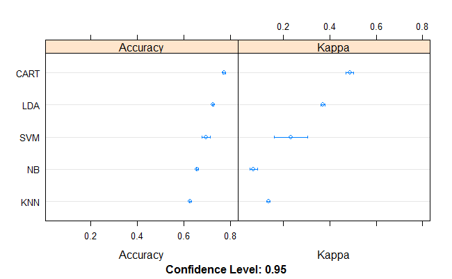

# Error for lda

Error for variable 15 as there is no variability in the data. This variable is the make of the vehicle. This variable is an integer. Let us try a first hand by making this variable a factor for all the data sets

Eventhough there were errors about no variability within groups, it might be for specific validation sets. The model was created. # Error for glmnet

Probably there was a class which had very few observations. Which has led to the solution not converging.Need to abandon this and try it out with lesser classes and see if it works.

When tried with lesser classes it worked. For the minority classes we can try other methods like SMOTE

```r
exp_train$class <- as.factor(exp_train$class,levels == c("Good_Portfolio-Medium","Medium_Portfolio-Medium"))
```

```
Error in as.factor(exp_train$class, levels == c("Good_Portfolio-Medium",  :
  unused argument (levels == c("Good_Portfolio-Medium", "Medium_Portfolio-Medium"))
```

# 15-Dec-2016

From the comparison of results, CART seems to be the best performing algorithm for the push through round. Need to understand more on the accuracy measures especially “Kappa”

# Ensemble methods

Now let us also try some ensemble methods. The below are the ensemble methods which we can try

Bagging : Bagged CART and Random Forest Boosting : Stochastic Gradient Boosting ( GBM)

```r
fit.rf <- train(class~.,data=exp_train,method="rf",metric=metric,trControl=trainSpot)
```

```
1 package is needed for this model and is not installed. (randomForest). Would you like to try to install it now?
1: yes
2: no
```

```r
yes
```

# Random Forest problem

The training was taking too long a time. It was prematurely ended.

Now let us check other indicators in the model. The following are the things which we need to check. 1. Relative importance of variables 2. Any inner proportions within the variables 3. Methodology for improving the existing metrics based on the new variable importance.

# Check 1 : Variable importance

Using the model fitted with each method

```r
varImp(fit.cart)
```

```
rpart variable importance

  only 20 most important variables shown (out of 89)

                 Overall
ORIGCREDITSCORE  100.000
APR               99.705
CUSTOMERFLATRATE  87.740
indscore          76.309
LOANAGE           24.060
PRINCIPALBALANCE  12.387
CASHSELLINGPRICE   5.438
MSRPPRICE          3.543
MAKE14             0.000
GMACYIELDRATE      0.000
MAKE10             0.000
STATENM            0.000
STATERI            0.000
PAYMENTAMT         0.000
STATEDC            0.000
STATEOK            0.000
STATEAL            0.000
STATEME            0.000
EXTENSION          0.000
DAYSPASTDUE        0.000
```

```r
#varImp(fit.svm) # Error
#varImp(fit.nb) # Error
varImp(fit.treebag)
```

```
treebag variable importance

  only 20 most important variables shown (out of 82)

                      Overall
indscore              100.000
ORIGCREDITSCORE        66.098
APR                    62.022
PRINCIPALBALANCE       61.850
CURRENTOSB             60.202
CUSTOMERFLATRATE       56.807
LOANAGE                49.545
SCHEDBAL               44.537
ORIGINALBALANCE        29.262
PAYMENTAMT             28.969
REMAININGTERM          28.106
ORIGPRINCIPALBAL       27.472
POSTCODE               25.080
CASHSELLINGPRICE       22.493
GMACYIELDRATE          19.477
MSRPPRICE              16.454
DAYSPASTDUE            10.524
MODEL                  10.385
PAYMENTMETHOD           9.568
OTHERAMTFINANCEDTOTAL   9.095
```

```r
#varImp(fit.knn) # Error
#varImp(fit.lda) # Error
# Another method of getting the variable importance
#filterVarImp(x=train_set[,-28],y=train_set$class)
```

Let us take a different approach in finding the model importance. Let us take each of the individual pool and find the variables which are important in each of the models